# Final_Project_EDA

Anna Hyunjung Kim

2026-04-16

```r
library(tidyverse)
student <- read.csv("./student/student-por.csv", header = TRUE, sep = ";")
```

# Variables Table

## Student Performance Dataset (UCI) – Variable Description

Dataset: Student Performance Dataset (https://archive.ics.uci.edu/dataset/320/student+performance)

This dataset contains information about secondary school students, including demographic characteristics, family background, academic behavior, and social factors. It is commonly used to analyze and predict student academic performance.

### Target Variable

| Variable | Description |
| --- | --- |
| G3 | Final grade (0–20) |
| G2 | Second period grade |
| G1 | First period grade |

### Demographic Variables

| Variable | Description |
| --- | --- |
| school | School attended (GP: Gabriel Pereira, MS: Mousinho da Silveira) |
| sex | Student’s sex (F: female, M: male) |
| age | Student’s age (15–22) |
| address | Home address type (U: urban, R: rural) |
| famsize | Family size (LE3: ≤3 members, GT3: >3 members) |
| Pstatus | Parent cohabitation status (T: together, A: apart) |

### Family Background

| Variable | Description |
| --- | --- |
| Medu | Mother’s education level (0–4) |
| Fedu | Father’s education level (0–4) |
| Mjob | Mother’s job |
| Fjob | Father’s job |
| guardian | Student’s guardian (mother, father, or other) |
| famsup | Family educational support (yes/no) |

### School and Study-related Variables

| Variable | Description |
| --- | --- |
| traveltime | Travel time to school (1: <15 min, 4: >1 hour) |
| studytime | Weekly study time (1: <2 hours, 4: >10 hours) |
| failures | Number of past class failures |
| schoolsup | Extra educational support from school (yes/no) |
| paid | Extra paid classes (yes/no) |
| activities | Participation in extracurricular activities (yes/no) |
| nursery | Attended nursery school (yes/no) |
| higher | Intention to pursue higher education (yes/no) |

### Social and Lifestyle Variables

| Variable | Description |
| --- | --- |
| internet | Internet access at home (yes/no) |
| romantic | In a romantic relationship (yes/no) |
| famrel | Quality of family relationships (1–5) |
| freetime | Free time after school (1–5) |
| goout | Going out with friends (1–5) |
| Dalc | Workday alcohol consumption (1–5) |
| Walc | Weekend alcohol consumption (1–5) |
| health | Current health status (1–5) |

# Exploratory Data Analysis (EDA)

```r
head(student)
```

```
##   school sex age address famsize Pstatus Medu Fedu     Mjob     Fjob     reason
## 1     GP   F  18       U     GT3       A    4    4  at_home  teacher     course
## 2     GP   F  17       U     GT3       T    1    1  at_home    other     course
## 3     GP   F  15       U     LE3       T    1    1  at_home    other      other
## 4     GP   F  15       U     GT3       T    4    2   health services       home
## 5     GP   F  16       U     GT3       T    3    3    other    other       home
## 6     GP   M  16       U     LE3       T    4    3 services    other reputation
##   guardian traveltime studytime failures schoolsup famsup paid activities
## 1   mother          2         2        0       yes     no   no         no
## 2   father          1         2        0        no    yes   no         no
## 3   mother          1         2        0       yes     no   no         no
## 4   mother          1         3        0        no    yes   no        yes
## 5   father          1         2        0        no    yes   no         no
## 6   mother          1         2        0        no    yes   no        yes
##   nursery higher internet romantic famrel freetime goout Dalc Walc health
## 1     yes    yes       no       no      4        3     4    1    1      3
## 2      no    yes      yes       no      5        3     3    1    1      3
## 3     yes    yes      yes       no      4        3     2    2    3      3
## 4     yes    yes      yes      yes      3        2     2    1    1      5
## 5     yes    yes       no       no      4        3     2    1    2      5
## 6     yes    yes      yes       no      5        4     2    1    2      5
##   absences G1 G2 G3
## 1        4  0 11 11
## 2        2  9 11 11
## 3        6 12 13 12
## 4        0 14 14 14
## 5        0 11 13 13
## 6        6 12 12 13
```

```r
str(student)
```

```
## 'data.frame':    649 obs. of  33 variables:
##  $ school    : chr  "GP" "GP" "GP" "GP" ...
##  $ sex       : chr  "F" "F" "F" "F" ...
##  $ age       : int  18 17 15 15 16 16 16 17 15 15 ...
##  $ address   : chr  "U" "U" "U" "U" ...
##  $ famsize   : chr  "GT3" "GT3" "LE3" "GT3" ...
##  $ Pstatus   : chr  "A" "T" "T" "T" ...
##  $ Medu      : int  4 1 1 4 3 4 2 4 3 3 ...
##  $ Fedu      : int  4 1 1 2 3 3 2 4 2 4 ...
##  $ Mjob      : chr  "at_home" "at_home" "at_home" "health" ...
##  $ Fjob      : chr  "teacher" "other" "other" "services" ...
##  $ reason    : chr  "course" "course" "other" "home" ...
##  $ guardian  : chr  "mother" "father" "mother" "mother" ...
##  $ traveltime: int  2 1 1 1 1 1 1 2 1 1 ...
##  $ studytime : int  2 2 2 3 2 2 2 2 2 2 ...
```

[output cut: 19 more lines]

```r
dim(student)
```

```
## [1] 649  33
```

### Distribution of Target Variables

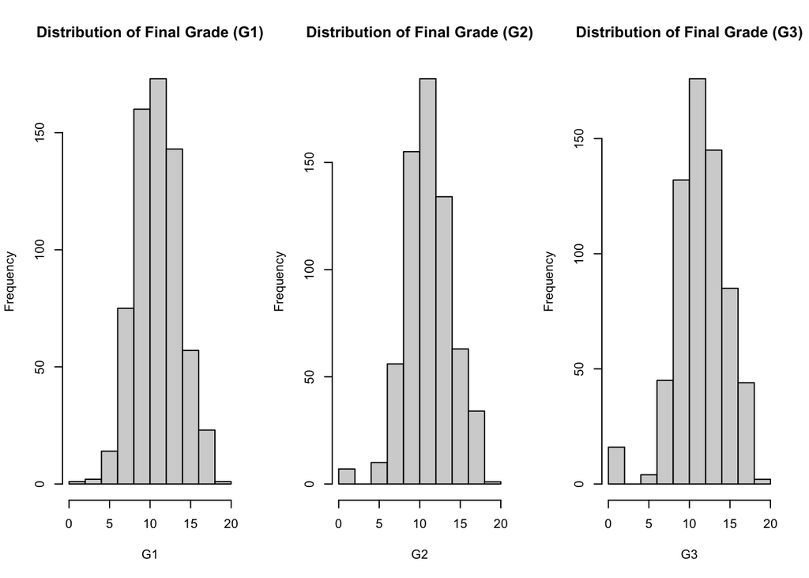

```r
par(mfrow = c(1, 3))

hist(student$G1, main = "Distribution of Final Grade (G1)", xlab = "G1")
hist(student$G2, main = "Distribution of Final Grade (G2)", xlab = "G2")
hist(student$G3, main = "Distribution of Final Grade (G3)", xlab = "G3")
```

The pattern of G1, G2, and G3 look similar. So, we need to check the correlation.

### Relationship Between G1, G2, and G3

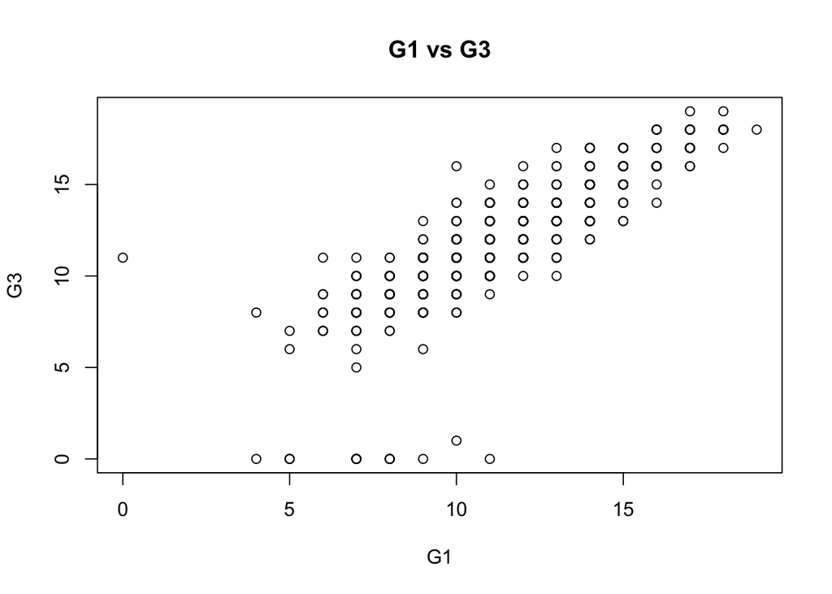

```r
plot(student$G1, student$G3, main = "G1 vs G3", xlab = "G1", ylab = "G3")
```

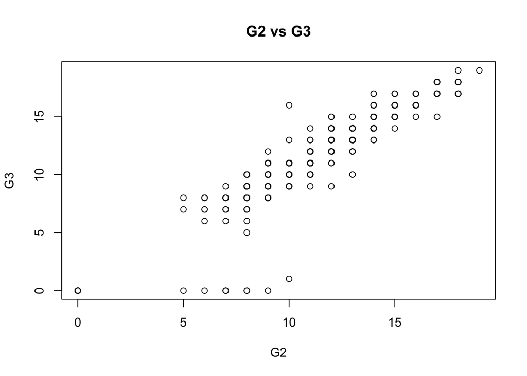

```r
plot(student$G2, student$G3, main = "G2 vs G3", xlab = "G2", ylab = "G3")
```

```r
cor(student$G1, student$G3)
```

```
## [1] 0.8263871
```

```r
cor(student$G2, student$G3)
```

```
## [1] 0.918548
```

The correlations are very high (0.83 and 0.92), indicating a strong linear relationship. Therefore, G3 is sufficient as the final outcome variable.

### Demographic Variables

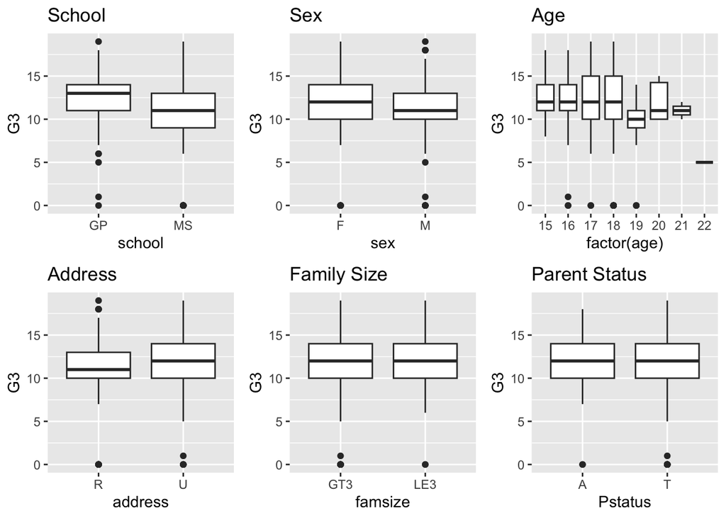

```r
library(ggplot2)
library(gridExtra)
p1 <- ggplot(student, aes(x = school, y = G3)) + geom_boxplot() + ggtitle("School")
p2 <- ggplot(student, aes(x = sex, y = G3)) + geom_boxplot() + ggtitle("Sex")
p3 <- ggplot(student, aes(x = factor(age), y = G3)) + geom_boxplot() + ggtitle("Age")
p4 <- ggplot(student, aes(x = address, y = G3)) + geom_boxplot() + ggtitle("Address")
p5 <- ggplot(student, aes(x = famsize, y = G3)) + geom_boxplot() + ggtitle("Family Size")
p6 <- ggplot(student, aes(x = Pstatus, y = G3)) + geom_boxplot() + ggtitle("Parent Status")

grid.arrange(p1, p2, p3, p4, p5, p6, ncol = 3)
```

- School: GP students score slightly higher than MS students.
- Sex: Female and male students have similar grades. Not a big difference.
- Age: Younger students (15–16) tend to score higher. Older students do worse.
- Address: Urban students score a little higher than rural students.
- Family Size & Parent Status: Almost no difference. These may not be important predictors.

### Family Background

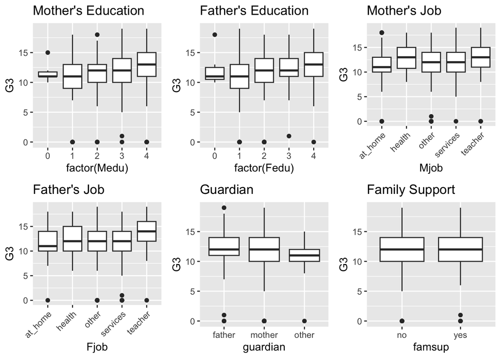

```r
p1 <- ggplot(student, aes(x = factor(Medu), y = G3)) + geom_boxplot() + ggtitle("Mother's Education")
p2 <- ggplot(student, aes(x = factor(Fedu), y = G3)) + geom_boxplot() + ggtitle("Father's Education")
p3 <- ggplot(student, aes(x = Mjob, y = G3)) + geom_boxplot() + ggtitle("Mother's Job") + theme(axis.text.x = element_text(angle = 45, hjust = 1))
p4 <- ggplot(student, aes(x = Fjob, y = G3)) + geom_boxplot() + ggtitle("Father's Job") + theme(axis.text.x = element_text(angle = 45, hjust = 1))
p5 <- ggplot(student, aes(x = guardian, y = G3)) + geom_boxplot() + ggtitle("Guardian")
p6 <- ggplot(student, aes(x = famsup, y = G3)) + geom_boxplot() + ggtitle("Family Support")

grid.arrange(p1, p2, p3, p4, p5, p6, ncol = 3)
```

### School and Study-related Variables

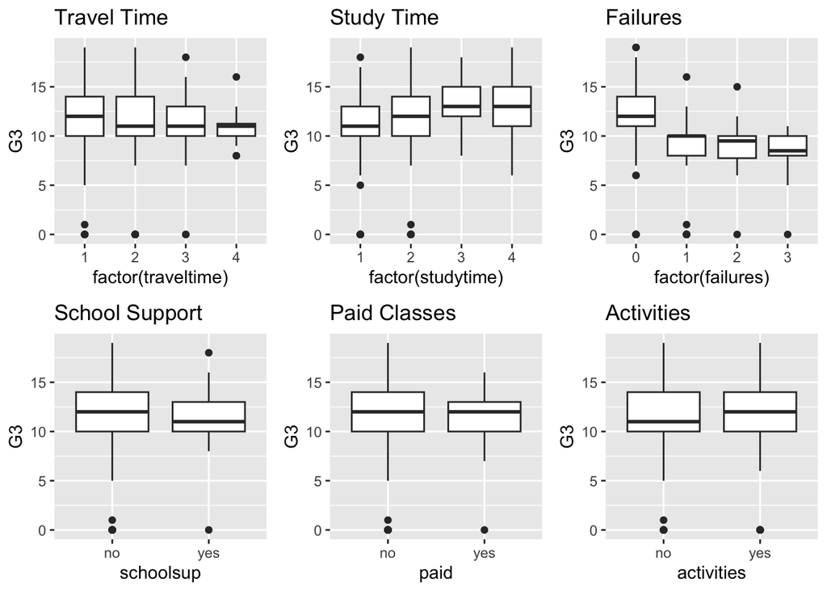

```r
p1 <- ggplot(student, aes(x = factor(traveltime), y = G3)) + geom_boxplot() + ggtitle("Travel Time")
p2 <- ggplot(student, aes(x = factor(studytime), y = G3)) + geom_boxplot() + ggtitle("Study Time")
p3 <- ggplot(student, aes(x = factor(failures), y = G3)) + geom_boxplot() + ggtitle("Failures")
p4 <- ggplot(student, aes(x = schoolsup, y = G3)) + geom_boxplot() + ggtitle("School Support")
p5 <- ggplot(student, aes(x = paid, y = G3)) + geom_boxplot() + ggtitle("Paid Classes")
p6 <- ggplot(student, aes(x = activities, y = G3)) + geom_boxplot() + ggtitle("Activities")

grid.arrange(p1, p2, p3, p4, p5, p6, ncol = 3)
```

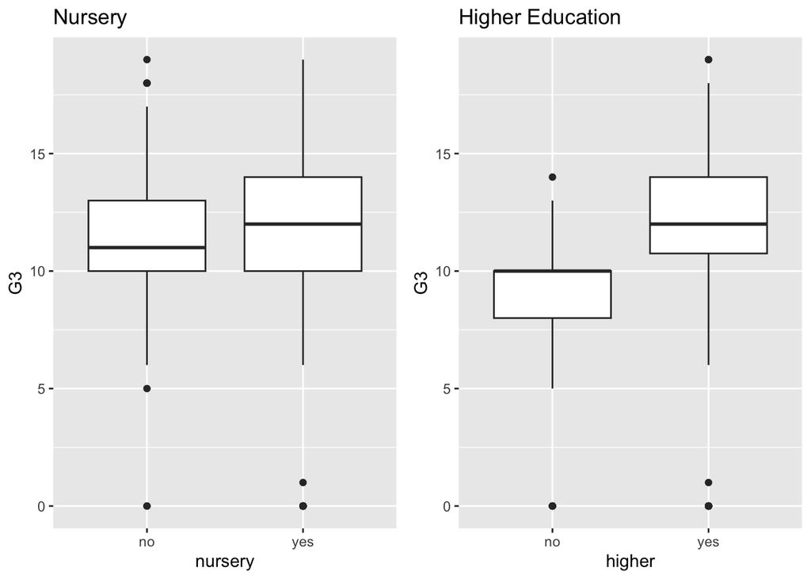

```r
p7 <- ggplot(student, aes(x = nursery, y = G3)) + geom_boxplot() + ggtitle("Nursery")
p8 <- ggplot(student, aes(x = higher, y = G3)) + geom_boxplot() + ggtitle("Higher Education")
grid.arrange(p7, p8, ncol = 2)
```

- Study Time: More study time -> higher grades. Makes sense! - Failures: Students with more past failures score much lower. This is a very strong predictor. - School Support: Students with school support score lower — maybe because struggling students get support. - Paid Classes: Little difference. - Activities: Little difference. - Higher Education (goal): Students who want to go to university score much higher. Big difference!

### Social and Lifestyle Variables

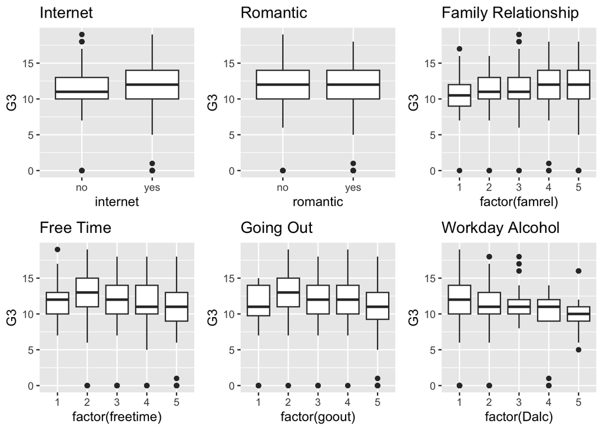

```r
p1 <- ggplot(student, aes(x = internet, y = G3)) + geom_boxplot() + ggtitle("Internet")
p2 <- ggplot(student, aes(x = romantic, y = G3)) + geom_boxplot() + ggtitle("Romantic")
p3 <- ggplot(student, aes(x = factor(famrel), y = G3)) + geom_boxplot() + ggtitle("Family Relationship")
p4 <- ggplot(student, aes(x = factor(freetime), y = G3)) + geom_boxplot() + ggtitle("Free Time")
p5 <- ggplot(student, aes(x = factor(goout), y = G3)) + geom_boxplot() + ggtitle("Going Out")
p6 <- ggplot(student, aes(x = factor(Dalc), y = G3)) + geom_boxplot() + ggtitle("Workday Alcohol")

grid.arrange(p1, p2, p3, p4, p5, p6, ncol = 3)
```

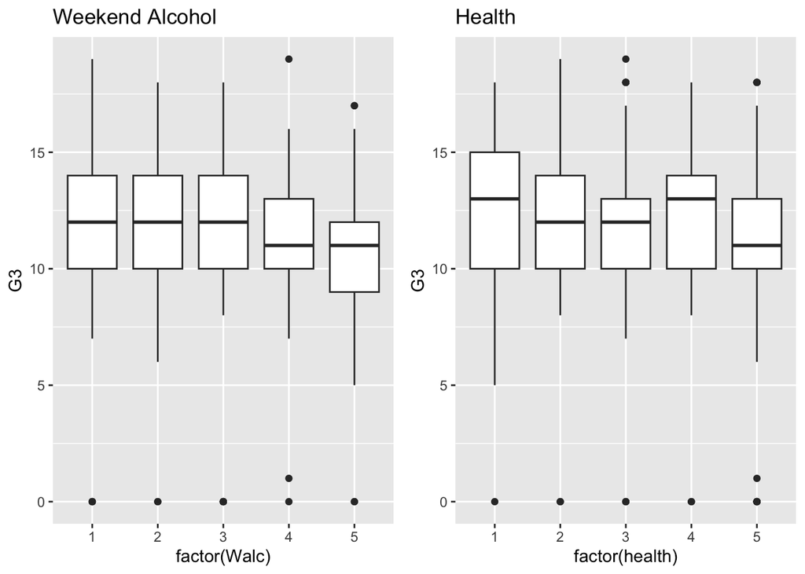

```r
p7 <- ggplot(student, aes(x = factor(Walc), y = G3)) + geom_boxplot() + ggtitle("Weekend Alcohol")
p8 <- ggplot(student, aes(x = factor(health), y = G3)) + geom_boxplot() + ggtitle("Health")

grid.arrange(p7, p8, ncol = 2)
```

- Internet: Students with internet access score slightly higher.
- Romantic: Little difference.
- Family Relationship: Not a strong trend.
- Free Time & Going Out: More free time or going out -> slightly lower grades, but not dramatic.
- Workday & Weekend Alcohol: Higher alcohol use -> slightly lower grades. Weak but noticeable trend.
- Health: No clear pattern. Health does not seem to predict grades well.